# Statistical Machine Learning Final Project: Gun Violence Data

Hayley Hadges, Ethan Deutsch, Em Hayward

5/7/2020

## **Introduction**

In our final project for Statistical Machine Learning, we’re using gun violence data from all US states including the District of Columbia ranging from January of 2018 to March of 2018, which include variables such as number of people killed, state, date, and number of participants just to name a few. With gun violence in the US as a relevant and continuous issue, we chose to analyze this dataset because we believe it is important to look deeper into the issue through data in the attempt to better understand it. To clean the data, we changed the categorical variable ‘date’ into the numerical variable ‘new_date’. We created a new variable ‘missing’ for all the missing data. From the ‘participant_gender’ variable, we created the ‘female_present’ variable. From the ‘participant_age’ variable we created the ‘teen_present’ and ‘child_present’ variables. We also removed multiple variables such as ‘address’ and ‘source_url’ that we deemed unusable.

In our project, we would like to formulate multiple different models that predict the variable n_killed (number of people killed in shooting). Throughout this modeling process, we look at the cross validated root mean squared error (RMSE) of each model and find the lowest to determine the ‘best model’. With this best model we plan to use the testing data to find which variables make the strongest impact on the number of people killed as well as look closer at how these variables affect the n_killed variable. Finding these variables with the largest impact and looking at their effect can be used to better understand gun violence and determine preventative measures for future gun violence.

## **Exploring Variables**

Before we begin modeling, we first look at some of the variables in the model more closely to determine which could be beneficial to use in the models.

```
## # A tibble: 1,827 x 2
##    city_or_county     n
##    <chr>          <int>
##  1 Chicago          214
##  2 Detroit          179
##  3 Baltimore        106
##  4 Houston           82
##  5 Milwaukee         73
##  6 New Orleans       67
##  7 Philadelphia      66
##  8 Washington        66
##  9 Boston            55
## 10 Columbus          51
## # ... with 1,817 more rows
```

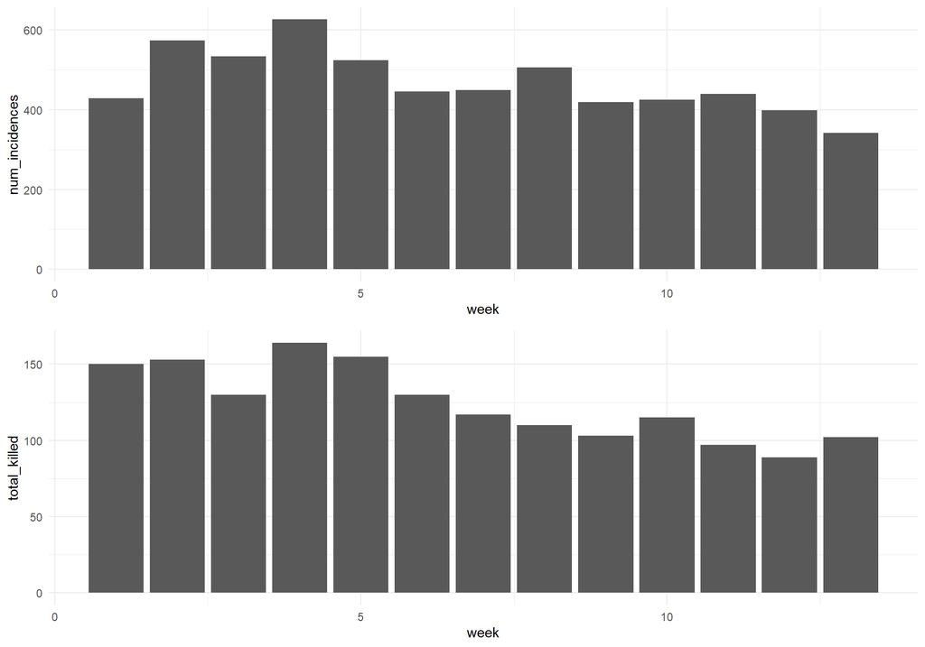

The first exploratory graph here is the number of shooting incidents that happen per week. The second plot, is the number of people killed per week in recorded shooting incidents. In the first graph it seems there is a slightly higher number of incidents that occur in the first five weeks of the year compared to the next eight weeks. There is a similar trend with the number of people killed, as four of the first five weeks have the highest death toll of the enntire 13-week data set.

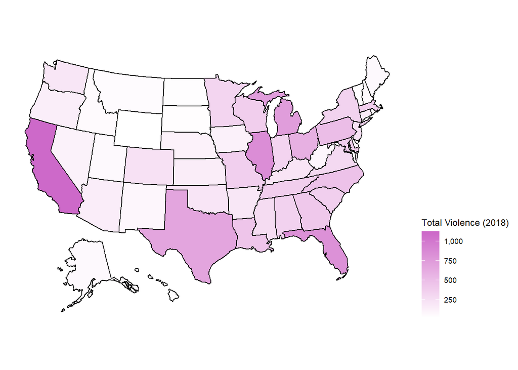

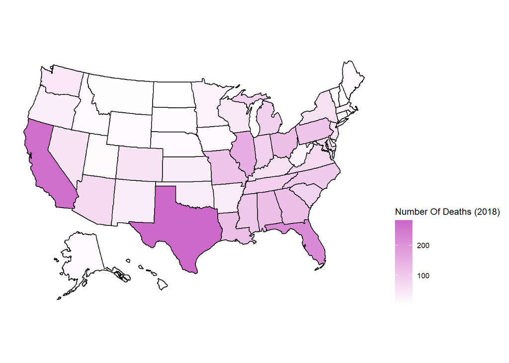

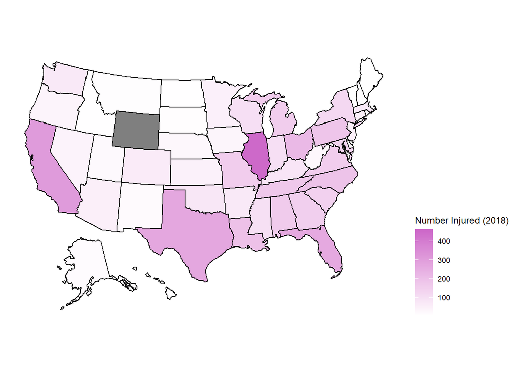

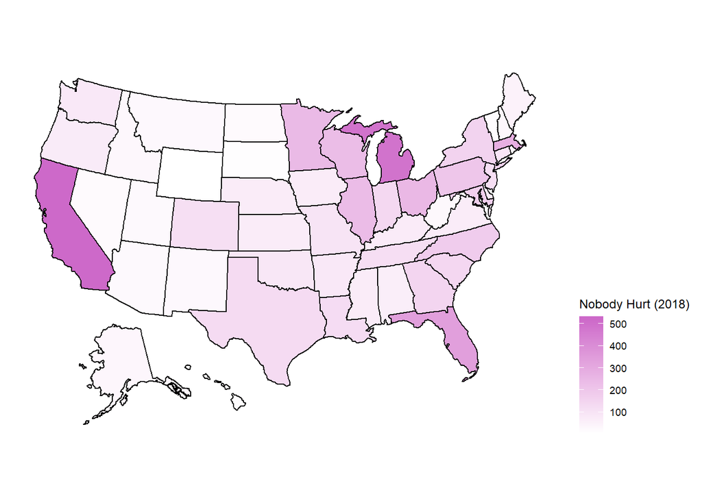

In these four US maps we can start by looking at the total violence, number of deaths by state. The darker states in the first three graphs indicate that there are more deaths and injuries in those states and lighter or white colours means there is less violence overall in those states. The four darkest states on average in the first three graphs are Texas, California, Illinois and Florida. The lighter regions of the United States are in the Mid-Eastern U.S., the upper Northeast and Alaska and Hawai’i. The fourth graph shows the number of people that were not hurt but still in a shooting incident. There is a larger switch of the darkness of colours in this graph which includes a significant darkening of Michigan, Wisconsin and Minnesota and the lightening of many Southern States.